# rapidFFR

Ignore - Hannah notes  
Files:  
Get SNR, SIG and NZ averaged over both runs from:  
snr_rapidIterations_concat_add  
snr_rapidIterations_concat_sub  
snr_stddIterations_concat_add  
snr_stddIterations_concat_sub

SIG and NZ seperate from each run (calculate z-score?) from:  
signal_mean_rapid_add  
signal_mean_rapid_sub  
nzfloor_mean_rapid_add  
nzfloor_mean_rapid_sub  
signal_mean_std_add  
signal_mean_std_sub  
nzfloor_mean_std_add  
nzfloor_mean_std_sub

## Exp 1: standard vs. rapid

### Quality of data

**Figure 1**:  
Schematic of standard, rapid and longRapid FFR. Showing what chunks/iterations etc. and common timings are.

**Figure 2**:  
2x2 panel  
top left: eeg std in red  
top right: eeg rapid in blue  
bottom left: Power std in red (showing harmonics)  
bottom right: Power rapid in blue (showing harmonics)  
*Caption*: Grand averaged time course and spectra representations of EEG recorded FFRs for standard (red) and rapid (blue) presentations. EEG data extracted from … electrodes….

### Q1: Is the signal sig. different from the noise?

**Figure 3 option 1**:

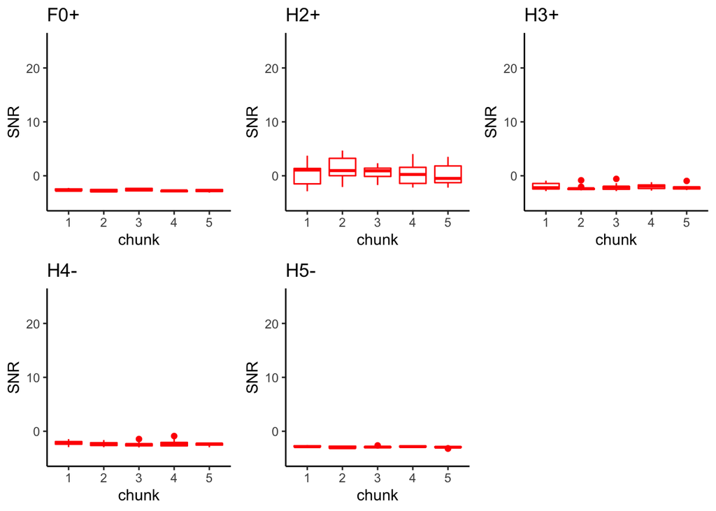

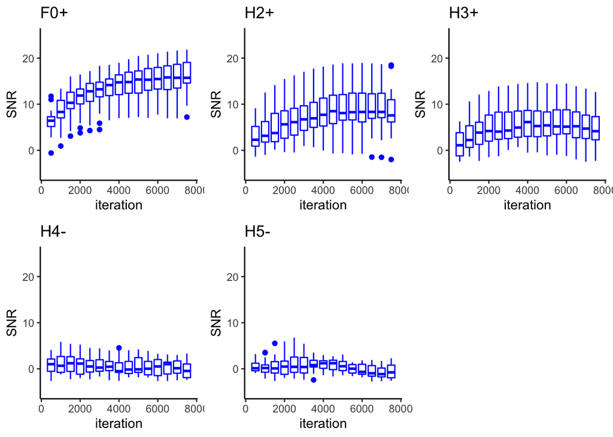

**Stats**:  
$\color{red}{\text{Q}}$: One-sample t-test for SNR to 0? Nope!  
$\color{red}{\text{Q}}$: ANOVA 1 (SNR) x 15 (iterations) - done. But this looks at the change across iterations rather than if signal is above noise.  
$\color{red}{\text{Q}}$: ANOVA 1 (snr) x 2 (std, rapid). To compare std to rapid at common iterations (1500, 3000, 4500, 6000, 7500?  
$\color{red}{\text{Q}}$: No stats here and do them on Figure 3: Option 2 data instead

ANOVA 1 (SNR) x 15 (iterations):  
- F0+ sig. effect of iterations  
- H2+ sig. effect of iterations  
- H3+ NO sig. effect of iterations  
- H4- NO sig. effect of iterations  
- H5- sig. effect of iterations

**Figure 3 option 2**:

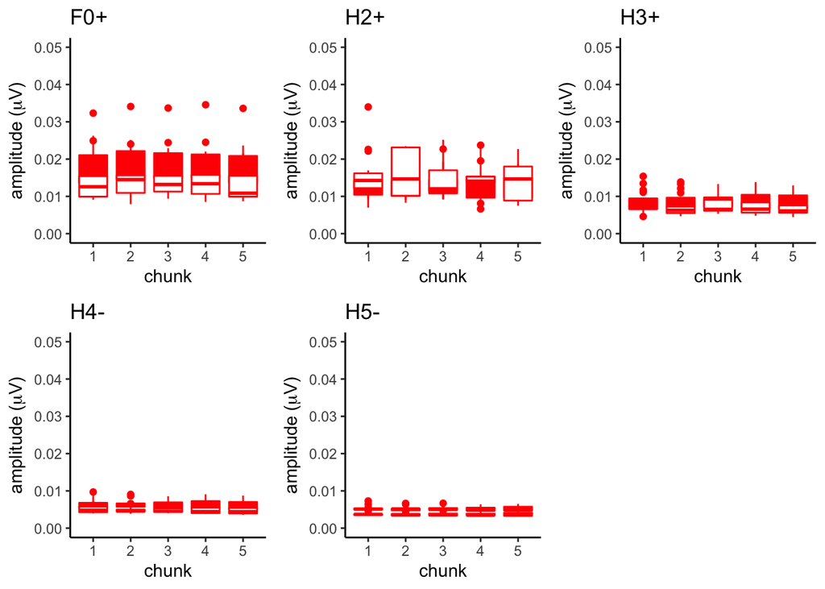

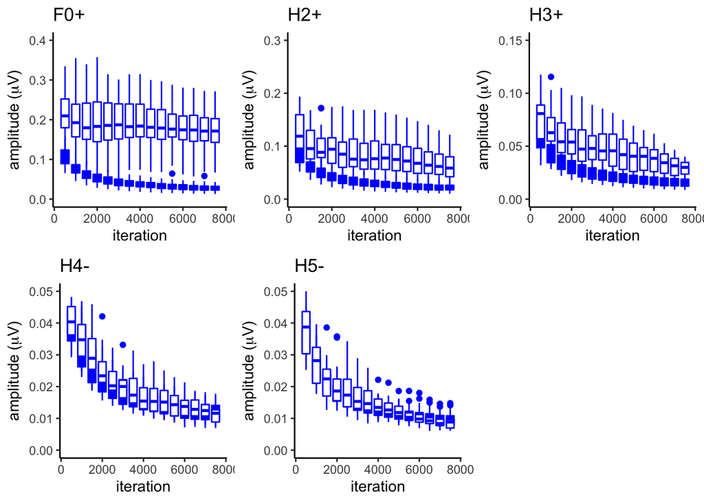

**Stats**:  
$\color{red}{\text{Q}}$: ANOVA 2 (signal, noise) x 15 (iterations). Does the difference between signal and noise changes across iterations.  
$\color{red}{\text{Q}}$: ANOVA 2 (signal, noise) x 2 (std, rapid). To compare std to rapid at common iterations (1500, 3000, 4500, 6000, 7500?

**Figure 4**:  
two graphs: add on left and sub on right  
- red = standard  
- blue = rapid  
- y axis: amplitude ($\mu$V peak)  
- x axis: F0 H2 H3 H4 H5

**Stats**:  
$\color{red}{\text{Q}}$: ANOVA 2 (std, rapid) x 5 (harmonics). This looks at if peak mag. is different between standard and rapid FFR across harmonics

**Figure 5**:  
correlations scatters for amplitude ($\mu$V peak) seperate plots for F1, F2, F3 etc.  
- grey scatter  
- black correlation line  
- y axis: rapid  
- x axis: standard  
$\color{red}{\text{Q}}$: which iteration should we use? 4500?? $\color{red}{\text{Q}}$: want z-score of run 1 v run 2?

### Q2: How long should the rapid FFR be?

$\color{red}{\text{Q}}$: fit at 63%?

## Exp 2: long rapid

### Q3: How does the signal and noise change over a 9 min recording?

**Figure 6 option 1**:

```
##        X             listener    run          chunk        condition
##  Min.   :   1.0   L01    : 15   add:315   Min.   : 1   longRapid:315
##  1st Qu.: 454.5   L02    : 15             1st Qu.: 4
##  Median : 908.0   L03    : 15             Median : 8
##  Mean   : 908.0   L04    : 15             Mean   : 8
##  3rd Qu.:1361.5   L05    : 15             3rd Qu.:12
##  Max.   :1815.0   L06    : 15             Max.   :15
##                   (Other):225
##   var_name       meanNZ           meanSIG             sdNZ
##  Freq1:315   Min.   :0.01403   Min.   :0.07417   Min.   :0.00743
##  Freq2:  0   1st Qu.:0.02879   1st Qu.:0.16071   1st Qu.:0.01502
##  Freq3:  0   Median :0.03595   Median :0.18516   Median :0.01871
##  Freq4:  0   Mean   :0.03909   Mean   :0.18806   Mean   :0.02044
##  Freq5:  0   3rd Qu.:0.04377   3rd Qu.:0.21692   3rd Qu.:0.02289
##  rms  :  0   Max.   :0.13632   Max.   :0.31423   Max.   :0.07372
##              NA's   :75        NA's   :75        NA's   :75
##      sdSIG             dprime             snr
##  Min.   :0.00791   Min.   :-0.1198   Min.   :-0.5124
##  1st Qu.:0.01606   1st Qu.: 6.1126   1st Qu.:12.6084
##  Median :0.01998   Median : 8.4718   Median :14.8976
##  Mean   :0.02182   Mean   : 8.2139   Mean   :14.0433
##  3rd Qu.:0.02449   3rd Qu.:10.2936   3rd Qu.:16.3300
##  Max.   :0.07008   Max.   :22.0298   Max.   :22.2681
##  NA's   :75        NA's   :75        NA's   :75
```

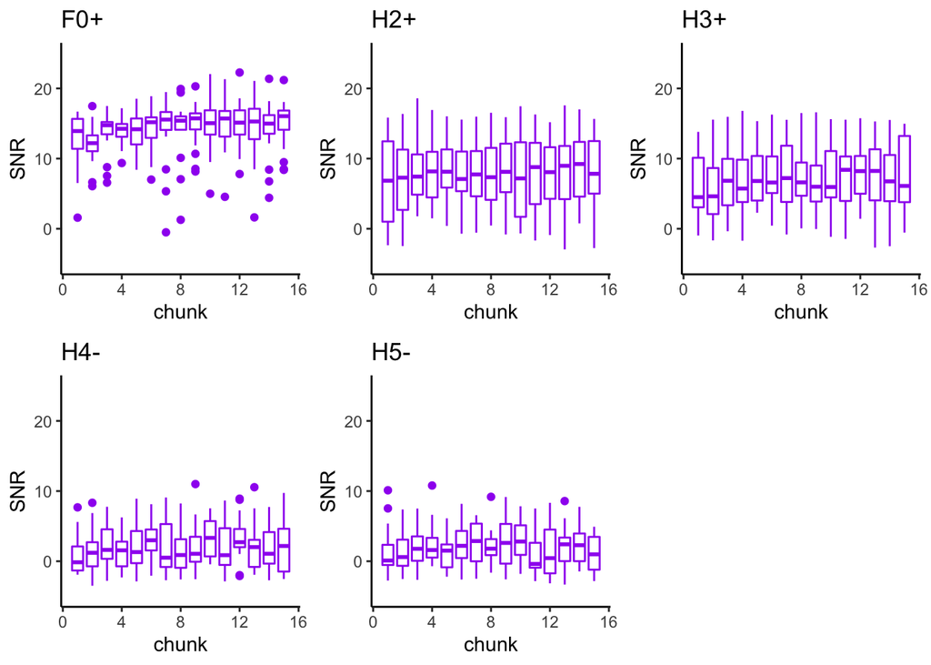

**Stats**:  
Option 1:  
ANOVA 1 (snr) x 15 (chunks). Does snr change across chunks?

- F0+ NO sig. effect of chunks
- H2+ NO sig. effect of chunks
- H3+ NO sig. effect of chunks
- H4- NO sig. effect of chunks
- H5- NO sig. effect of chunks  
  => SNR does not significantly change over the 9 mins recording for any of the harmonics.

**Figure 6 option 2**:

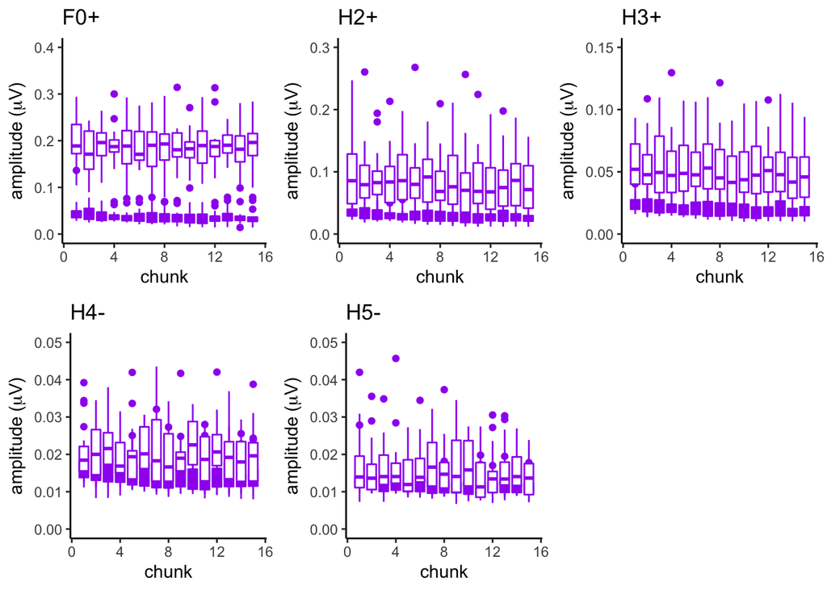

**Stats**:  
Option 2:  
$\color{red}{\text{Q}}$: How do you do a 2 (signal, noise) x 15 (chunk) ANOVA in r!?

ANOVA 1 (signal) x 15 (chunks). Does the signal change across chunks?

- F0+ NO sig. effect of chunks
- H2+ NO sig. effect of chunks
- H3+ NO sig. effect of chunks
- H4- NO sig. effect of chunks
- H5- NO sig. effect of chunks  
  => mean signal does not significantly change over the 9 mins recording for any of the harmonics.

ANOVA 1 (noise) x 15 (chunks). Does the noise change across chunks?

- F0+ NO sig. effect of chunks
- H2+ NO sig. effect of chunks
- H3+ NO sig. effect of chunks
- H4- NO sig. effect of chunks
- H5- NO sig. effect of chunks  
  => mean noise does not significantly change over the 9 mins recording for any of the harmonics.